# Social Network Analysis

Kim Pham

10/24/2017

## 0. Import libraries

```r
library(igraph)
library(dplyr)
library(tidyr)
```

# Project 1 - Visualizing Teacher-Student Discplinary Interactions

## 1. Upload data file

Data file description: Each row is a disciplinary action from a teacher to a student so the first line shows that teacher “E” sent student “21” to the principal. It also shows the gender of both the teacher and student and the student’s main elective field of study (“major”“) and the field that the teacher instructs in (”t.expertise“).

```r
df <- read.csv("Data/discipline-data.csv")
head(df)
```

```
##   tid stid s.gender s.major t.gender t.expertise
## 1   E   21   female     art   female         art
## 2   A    4     male    math   female     biology
## 3   A   25     male biology   female     biology
## 4   E   15   female english   female         art
## 5   D    1     male biology   female         art
## 6   E    8     male english   female         art
```

## 2. Process and structure data for igraph

igraph requires (1) “edge list” and (2) “vertex list”: * edge list contains a list of all the relationships between students and teachers and any characteristics of those edges that we might be interested in. There are two essential variables in the edge list a “from” variable and a “to” variable that descibe the relationships between vertices (a disciplinary action is given “from” and teacher “to” a student). * vertix list contains all the characteristics of those vertices, in our case gender and major.

```r
# change id from integert to factor
df$stid <- as.factor(df$stid)

# edge list (i.e. from, to, and count information)
df2 <- dplyr::select(df, tid, stid)
EDGE <- dplyr::count(df2, tid, stid)
names(EDGE) <- c("from", "to", "count")
head(EDGE)
```

```
## # A tibble: 6 x 3
##   from  to    count
##   <fct> <fct> <int>
## 1 A     2         1
## 2 A     3         1
## 3 A     4         2
## 4 A     5         1
## 5 A     18        1
## 6 A     22        1
```

```r
# vertex list

# list of unique teachers
V.TCH <- dplyr::select(df, tid, t.gender, t.expertise)
V.TCH <- unique(V.TCH)
V.TCH$group <- "teacher"
V.TCH
```

```
##    tid t.gender t.expertise   group
## 1    E   female         art teacher
## 2    A   female     biology teacher
## 5    D   female         art teacher
## 7    B     male        math teacher
## 10   C     male     biology teacher
```

```r
# list of unique students
V.STD <- dplyr::select(df, stid, s.gender, s.major)
V.STD <- unique(V.STD)
V.STD$group <- "student"

# join list of teachers and students into one dataframe
names(V.TCH) <- c("id", "gender", "topic", "group")
names(V.STD) <- c("id", "gender", "topic", "group")
VERTEX <- dplyr::bind_rows(V.TCH, V.STD)
head(VERTEX)
```

```
##   id gender   topic   group
## 1  E female     art teacher
## 2  A female biology teacher
## 3  D female     art teacher
## 4  B   male    math teacher
## 5  C   male biology teacher
## 6 21 female     art student
```

## 3. Plot the social network using igraph

The graph below shows “directed = TRUE” relationships since discipline is being given from a teacher to a student. The first graph shows the vertex separated by gender and the edge width is relational to the count of interactions.

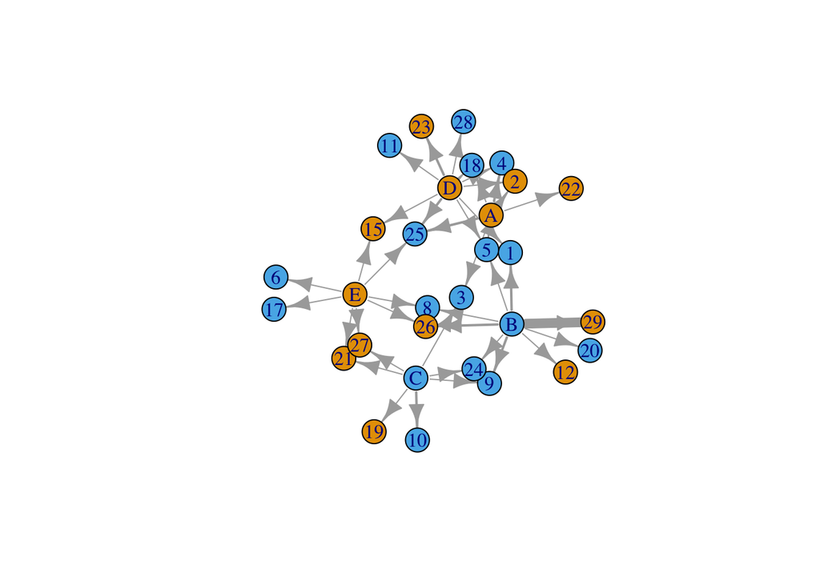

```r
# "directed = TRUE" - our graph is directed
g <- graph.data.frame(EDGE, directed=TRUE, vertices=VERTEX)
plot(g,layout=layout.fruchterman.reingold, vertex.color=VERTEX$gender, edge.width=EDGE$count)
```

The second graph shows the vertex size in terms of the number of disciplinary actions they have recieved (i.e. students) or the number of disciplinary actions they have given out (i.e. teachers).

```r
# count displinary actions teachers have given out and students have received
teach_EDGE <- EDGE %>% group_by(from) %>% summarise(sum = sum(count))
stud_EDGE <- EDGE %>% group_by(to) %>% summarise(sum = sum(count))
names(teach_EDGE) <- c("id", "sum")
names(stud_EDGE) <- c("id", "sum")

# join list of teachers and students into one dataframe
EDGE2 <- bind_rows(teach_EDGE, stud_EDGE)
head(EDGE2)
```

```
## # A tibble: 6 x 2
##   id      sum
##   <chr> <int>
## 1 A         9
## 2 B        19
## 3 C         8
## 4 D        12
## 5 E         8
## 6 1         3
```

```r
VERTEX2 <- left_join(EDGE2, VERTEX, by="id")
head(VERTEX2)
```

```
## # A tibble: 6 x 5
##   id      sum gender topic   group
##   <chr> <int> <fct>  <chr>   <chr>
## 1 A         9 female biology teacher
## 2 B        19 male   math    teacher
## 3 C         8 male   biology teacher
## 4 D        12 female art     teacher
## 5 E         8 female art     teacher
## 6 1         3 male   biology student
```

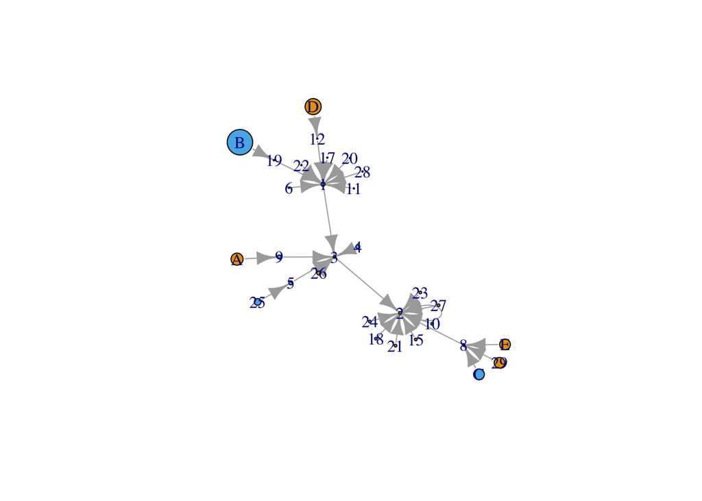

```r
# plot
g2 <- graph.data.frame(EDGE2, directed=TRUE, vertices=VERTEX2)
plot(g2,layout=layout.fruchterman.reingold, vertex.color=VERTEX2$gender, vertex.size=EDGE2$sum)
```

# Project 2: Visualizing person network on shared courses

## 1. Upload data file

```r
class_df <- read.csv("Data/HUDK4050_2017_SNA_classes.csv") # import data
```

## 2. Process and structure data for igraph

```r
# process data
class_df <- class_df[-26,] # remove bad data
class_df <- mutate(class_df, ID = row_number()) # add id column
class_df <- select(class_df, -First.Name, -Last.Name, -email) # remove variables not needed
class_df <- gather(class_df, key = course, value = section, 1:6) # gather section names
class_df <- filter(class_df,section>=1) # remove rows where sections do not exist
class_df$keyvalue <- 1 # add new keyvalue to spread by
class_df <- class_df %>% select(-course) %>% spread(section,keyvalue) # spread

# create prerson to person matrix
class_df[is.na(class_df)] <- 0
class_m <- as.matrix(class_df[,2:19])
rownames(class_m) <- class_df[,1]
class_m
```

```
##    A&HB4021 A&HB4021  A&HB4802 A&HL4076 A&HM4358  BISTP8120 CCPX4037
## 1         0         0        0        0         0         0        0
## 2         0         0        0        0         0         0        0
## 3         0         0        0        0         0         0        0
## 4         0         0        0        0         0         0        0
## 5         0         0        0        0         0         0        0
## 6         0         0        0        0         0         0        0
## 7         0         0        0        0         0         1        0
## 8         0         0        0        0         0         0        0
## 9         1         0        1        1         0         0        0
## 10        0         0        0        0         0         0        0
## 11        0         0        0        0         0         0        0
## 12        0         0        0        0         0         0        0
## 13        0         0        0        0         0         0        0
## 14        0         0        0        0         0         0        1
```

[output cut: 81 more lines]

```r
person_m <- class_m %*% t(class_m)
person_m
```

```
##    1 2 3 4 5 6 7 8 9 10 11 12 13 14 15 16 17 18 19 20 21 22 23 24 25 26 27
## 1  1 1 1 1 1 1 1 1 1  0  1  0  1  0  1  0  1  1  1  0  1  1  1  1  0  0  1
## 2  1 1 1 1 1 1 1 1 1  0  1  0  1  0  1  0  1  1  1  0  1  1  1  1  0  0  1
## 3  1 1 1 1 1 1 1 1 1  0  1  0  1  0  1  0  1  1  1  0  1  1  1  1  0  0  1
## 4  1 1 1 1 1 1 1 1 1  0  1  0  1  0  1  0  1  1  1  0  1  1  1  1  0  0  1
## 5  1 1 1 1 3 1 1 1 1  0  1  0  1  0  1  0  1  1  2  0  1  1  1  1  0  0  1
## 6  1 1 1 1 1 1 1 1 1  0  1  0  1  0  1  0  1  1  1  0  1  1  1  1  0  0  1
## 7  1 1 1 1 1 1 2 1 1  0  1  0  1  0  1  0  1  1  1  0  1  1  1  1  0  0  1
## 8  1 1 1 1 1 1 1 1 1  0  1  0  1  0  1  0  1  1  1  0  1  1  1  1  0  0  1
## 9  1 1 1 1 1 1 1 1 4  0  1  0  1  0  1  0  1  1  1  0  3  1  3  1  0  0  1
## 10 0 0 0 0 0 0 0 0 0  1  0  0  0  0  0  0  0  0  0  0  0  0  0  0  0  0  0
## 11 1 1 1 1 1 1 1 1 1  0  1  0  1  0  1  0  1  1  1  0  1  1  1  1  0  0  1
## 12 0 0 0 0 0 0 0 0 0  0  0  0  0  0  0  0  0  0  0  0  0  0  0  0  0  0  0
## 13 1 1 1 1 1 1 1 1 1  0  1  0  1  0  1  0  1  1  1  0  1  1  1  1  0  0  1
## 14 0 0 0 0 0 0 0 0 0  0  0  0  0  2  0  0  0  0  0  0  0  0  0  0  0  0  0
```

[output cut: 49 more lines]

## 3. Plot the social network using igraph

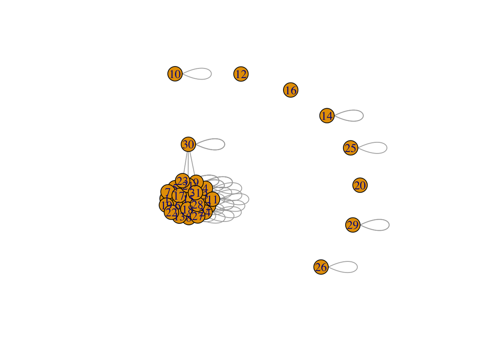

```r
g3 <- graph.adjacency(person_m, mode = "upper")
plot(g3,layout=layout.fruchterman.reingold)
```

## 4. Analyze network

“The vertex and edge betweenness are (roughly) defined by the number of geodesics (shortest paths) going through a vertex or an edge” [source](https://igraph.org/r/doc/betweenness.html)

```r
b <- betweenness(g3, v = V(g3), directed = TRUE, weights = NULL,
  nobigint = TRUE, normalized = FALSE)
b <- as.data.frame(b)
b$id <- rownames(b)
b <- filter(b, b==max(b))
b
```

```
##          b id
## 1 6.333333  9
## 2 6.333333 21
## 3 6.333333 23
```

Students 9, 21, and 23 have the most crossover of courses with other students.

“The degree of a vertex is its most basic structural property, the number of its adjacent edges.” [source](https://igraph.org/r/doc/degree.html)

```r
d <- degree(g3, v = V(g3), mode = c("total"),
  loops = TRUE, normalized = FALSE)
d <- as.data.frame(d)
d$id <- rownames(d)
d <- filter(d, d==max(d))
d
```

```
##    d id
## 1 34  9
## 2 34 23
```

Students 9 and 23 have the most total adjacent edges, or in other words, are most connected to and from other students.